# The Geography of Trauma: Deciphering the Life and Death Patterns of NYC Shootings

Bhaveeasheshwar Eswaran

2026-04-25

# 1 The Question Behind the Numbers

New York City publishes every shooting incident the NYPD has logged since 2006 — Each row is one incident: where, when, who was shot, and whether they survived. That’s a lot of ground to cover, so this report focuses on a few questions that feel tractable and worth asking —

- Which boroughs bear the most shooting violence, and does that vary by whether the shooting is fatal?
- Who is getting shot, in terms of the demographic profile the data captures?
- Has volume changed over time, especially around the pandemic years?
- When do shootings cluster — hour of day, day of week?
- Can we predict whether a shooting will be fatal from variables available at incident time?

# 2 Setup

```r
library(tidyverse)
library(lubridate)
library(scales)
library(janitor)
library(broom)

borough_colors <- c(
  "BRONX"         = "#E63946",
  "BROOKLYN"      = "#457B9D",
  "MANHATTAN"     = "#2A9D8F",
  "QUEENS"        = "#E9C46A",
  "STATEN ISLAND" = "#A8DADC"
)
```

# 3 Getting the Data

```r
raw <- read_csv(
  "https://data.cityofnewyork.us/api/views/833y-fsy8/rows.csv?accessType=DOWNLOAD",
  show_col_types = FALSE
) %>% clean_names()
```

# 4 Cleaning

The raw file has 21 columns. A handful are useful; most aren’t. Coordinate columns, jurisdiction codes, and location description are either too sparse or too granular to add anything here, so I’m dropping them upfront. Perpetrator fields sound useful but they’re missing in over 60% of rows — mostly because the perpetrator was never identified — so they won’t factor into the model.

```r
age_levels <- c("<18", "18-24", "25-44", "45-64", "65+")

shootings <- raw %>%
  select(occur_date, occur_time, boro, statistical_murder_flag,
         vic_age_group, vic_sex, vic_race) %>%
  mutate(
    date    = mdy(occur_date),
    hour    = hour(hms(occur_time)),
    year    = year(date),
    wday    = wday(date, label = TRUE, week_start = 1),
    borough = factor(boro),
    fatal   = as.integer(statistical_murder_flag),
    vic_age = factor(
      ifelse(vic_age_group %in% age_levels, vic_age_group, NA),
      levels = age_levels,
      ordered = TRUE
    ),
    vic_sex  = factor(ifelse(vic_sex %in% c("M", "F"), vic_sex, NA)),
    vic_race = ifelse(vic_race %in% c("UNKNOWN", "(null)"), NA, vic_race)
  ) %>%
  select(-occur_date, -occur_time, -boro, -statistical_murder_flag,
         -vic_age_group) %>%
  filter(!is.na(date), year <= 2024)
```

## 4.1 What we’re left with

```r
cat(nrow(shootings), "incidents from", format(min(shootings$date), "%b %Y"),
    "to", format(max(shootings$date), "%b %Y"), "\n")
```

```
## 29744 incidents from Jan 2006 to Dec 2024
```

```r
shootings %>% count(year) %>% print(n = 25)
```

```
## # A tibble: 19 × 2
##     year     n
##    <dbl> <int>
##  1  2006  2055
##  2  2007  1887
##  3  2008  1959
##  4  2009  1828
##  5  2010  1912
##  6  2011  1939
##  7  2012  1717
##  8  2013  1339
##  9  2014  1464
## 10  2015  1434
## 11  2016  1208
## 12  2017   970
## 13  2018   958
## 14  2019   967
## 15  2020  1948
## 16  2021  2011
## 17  2022  1716
## 18  2023  1250
## 19  2024  1182
```

## 4.2 Missingness

```r
shootings %>%
  summarise(across(c(vic_age, vic_sex, vic_race, fatal),
                   ~ round(mean(is.na(.x)) * 100, 1))) %>%
  pivot_longer(everything(), names_to = "field", values_to = "pct_missing") %>%
  arrange(desc(pct_missing)) %>%
  knitr::kable(col.names = c("Field", "% Missing"))
```

| Field | % Missing |
| --- | --- |
| vic_age | 0.2 |
| vic_race | 0.2 |
| vic_sex | 0.0 |
| fatal | 0.0 |

Victim fields are mostly complete. `fatal` is fully populated — that’s the outcome we care about.

# 5 Exploratory Analysis

## 5.1 Borough by borough: raw volume

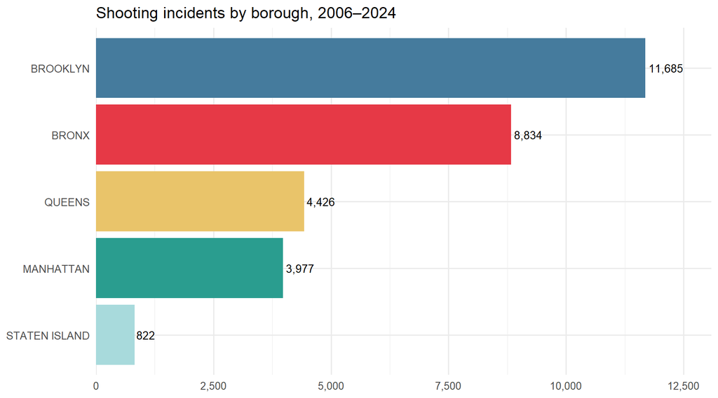

```r
shootings %>%
  count(borough) %>%
  mutate(borough = fct_reorder(borough, n)) %>%
  ggplot(aes(n, borough, fill = borough)) +
  geom_col(show.legend = FALSE) +
  geom_text(aes(label = comma(n)), hjust = -0.1, size = 3.5) +
  scale_fill_manual(values = borough_colors) +
  scale_x_continuous(labels = comma, expand = expansion(mult = c(0, 0.12))) +
  labs(title = "Shooting incidents by borough, 2006–2024", x = NULL, y = NULL) +
  theme_minimal(base_size = 12)
```

Brooklyn and the Bronx together account for around two-thirds of all incidents. Staten Island is in a different universe by comparison.

## 5.2 Does fatality rate track with volume?

Not necessarily — a high-volume borough could still have a lower proportion of fatal shootings.

```r
shootings %>%
  group_by(borough) %>%
  summarise(n = n(), fatal_pct = mean(fatal, na.rm = TRUE) * 100) %>%
  arrange(desc(fatal_pct)) %>%
  knitr::kable(digits = 1, col.names = c("Borough", "Incidents", "Fatal %"))
```

| Borough | Incidents | Fatal % |
| --- | --- | --- |
| STATEN ISLAND | 822 | 20.7 |
| QUEENS | 4426 | 19.7 |
| BRONX | 8834 | 19.6 |
| BROOKLYN | 11685 | 19.5 |
| MANHATTAN | 3977 | 18.1 |

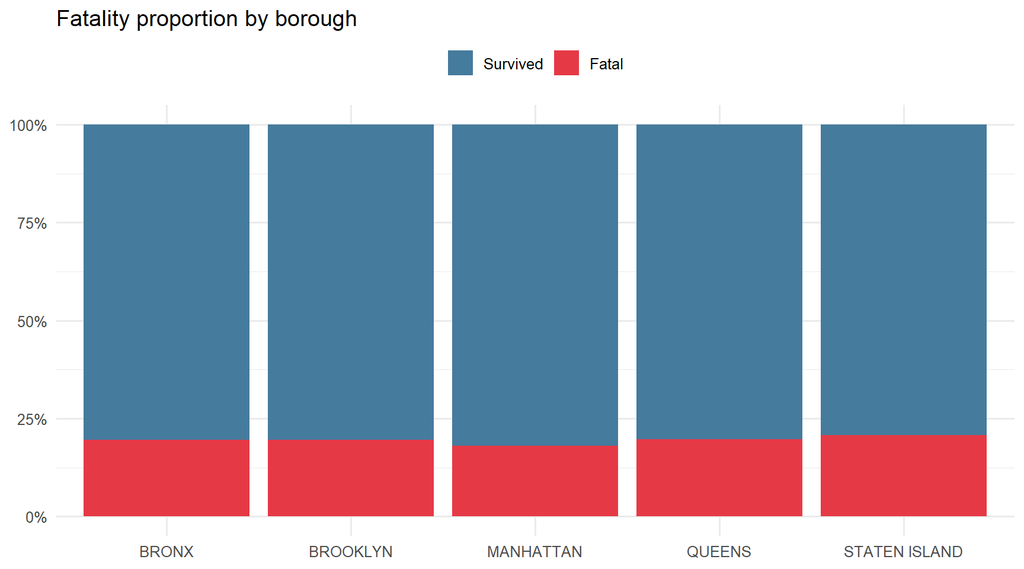

```r
shootings %>%
  filter(!is.na(fatal)) %>%
  count(borough, fatal) %>%
  mutate(fatal = factor(fatal, labels = c("Survived", "Fatal"))) %>%
  ggplot(aes(borough, n, fill = fatal)) +
  geom_col(position = "fill") +
  scale_y_continuous(labels = percent) +
  scale_fill_manual(values = c("Survived" = "#457B9D", "Fatal" = "#E63946")) +
  labs(title = "Fatality proportion by borough", x = NULL, y = NULL, fill = NULL) +
  theme_minimal(base_size = 12) +
  theme(legend.position = "top")
```

The borough ranking by fatality rate doesn’t mirror the volume ranking closely — which hints that borough alone isn’t the whole story.

## 5.3 Who is getting shot?

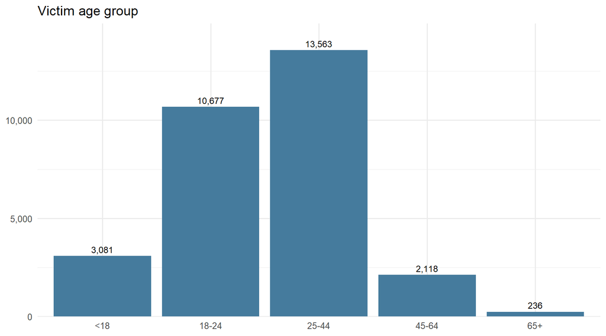

```r
shootings %>%
  filter(!is.na(vic_age)) %>%
  count(vic_age) %>%
  ggplot(aes(vic_age, n)) +
  geom_col(fill = "#457B9D") +
  geom_text(aes(label = comma(n)), vjust = -0.5, size = 3.3) +
  scale_y_continuous(labels = comma, expand = expansion(mult = c(0, 0.1))) +
  labs(title = "Victim age group", x = NULL, y = NULL) +
  theme_minimal(base_size = 12)
```

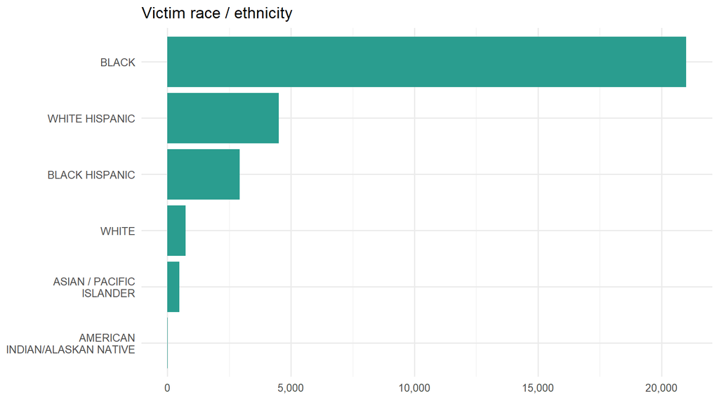

```r
shootings %>%
  filter(!is.na(vic_race)) %>%
  count(vic_race) %>%
  mutate(vic_race = str_wrap(vic_race, 22),
         vic_race = fct_reorder(vic_race, n)) %>%
  ggplot(aes(n, vic_race)) +
  geom_col(fill = "#2A9D8F") +
  scale_x_continuous(labels = comma) +
  labs(title = "Victim race / ethnicity", x = NULL, y = NULL) +
  theme_minimal(base_size = 12)
```

The 25–44 bracket is the largest group by a wide margin. The racial pattern is stark — Black New Yorkers represent the overwhelming majority of victims. This dataset records incidents, not population-adjusted risk, so reading it as a rate would require census denominators this file doesn’t carry.

## 5.4 The trend line

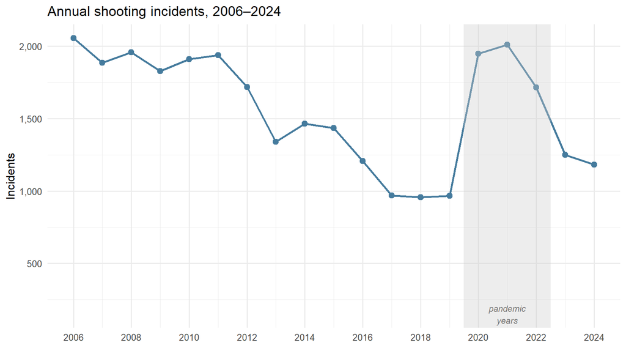

```r
shootings %>%
  count(year) %>%
  ggplot(aes(year, n)) +
  geom_line(color = "#457B9D", linewidth = 1) +
  geom_point(color = "#457B9D", size = 2.5) +
  annotate("rect", xmin = 2019.5, xmax = 2022.5,
           ymin = -Inf, ymax = Inf, fill = "grey80", alpha = 0.35) +
  annotate("text", x = 2021, y = 150, label = "pandemic\nyears",
           size = 3, color = "grey45", fontface = "italic") +
  scale_x_continuous(breaks = seq(2006, 2024, 2)) +
  scale_y_continuous(labels = comma) +
  labs(title = "Annual shooting incidents, 2006–2024", x = NULL, y = "Incidents") +
  theme_minimal(base_size = 12)
```

Shootings fell steadily from 2006 through 2019 — roughly halving over that stretch. Then 2020 snapped the trend sharply upward. By 2022 it had started pulling back again, but we’re not back to pre-pandemic levels through 2024.

## 5.5 When do they happen?

### 5.5.1 By hour

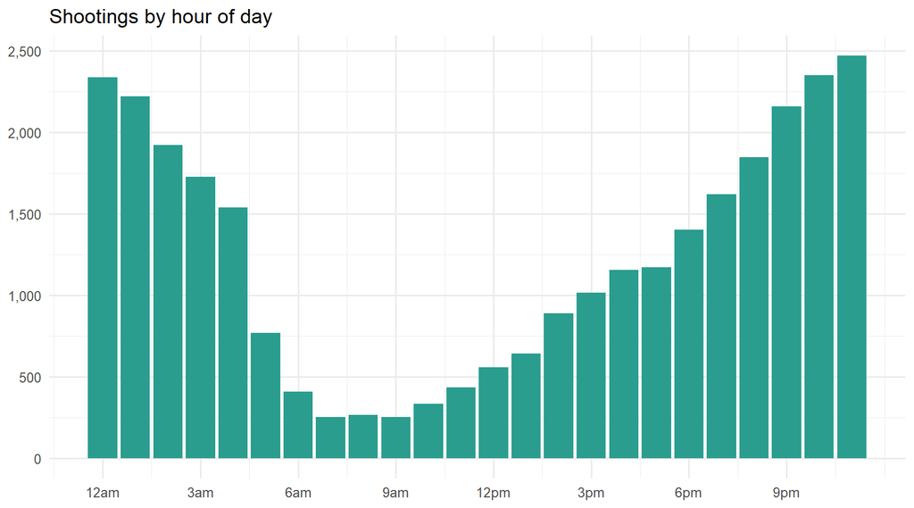

```r
shootings %>%
  count(hour) %>%
  ggplot(aes(hour, n)) +
  geom_col(fill = "#2A9D8F") +
  scale_x_continuous(breaks = seq(0, 23, 3),
                     labels = c("12am","3am","6am","9am","12pm","3pm","6pm","9pm")) +
  scale_y_continuous(labels = comma) +
  labs(title = "Shootings by hour of day", x = NULL, y = NULL) +
  theme_minimal(base_size = 12)
```

### 5.5.2 By day of week

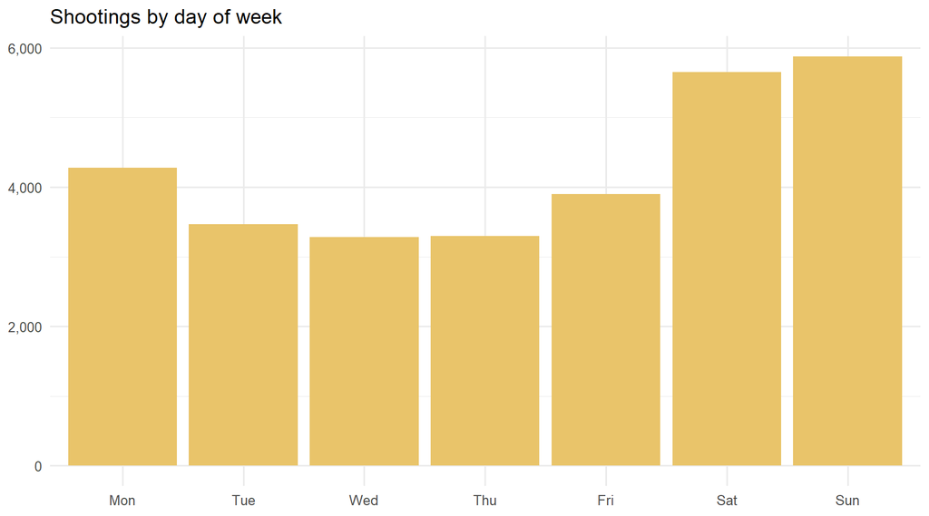

```r
shootings %>%
  count(wday) %>%
  ggplot(aes(wday, n)) +
  geom_col(fill = "#E9C46A") +
  scale_y_continuous(labels = comma) +
  labs(title = "Shootings by day of week", x = NULL, y = NULL) +
  theme_minimal(base_size = 12)
```

### 5.5.3 Hour × day heatmap

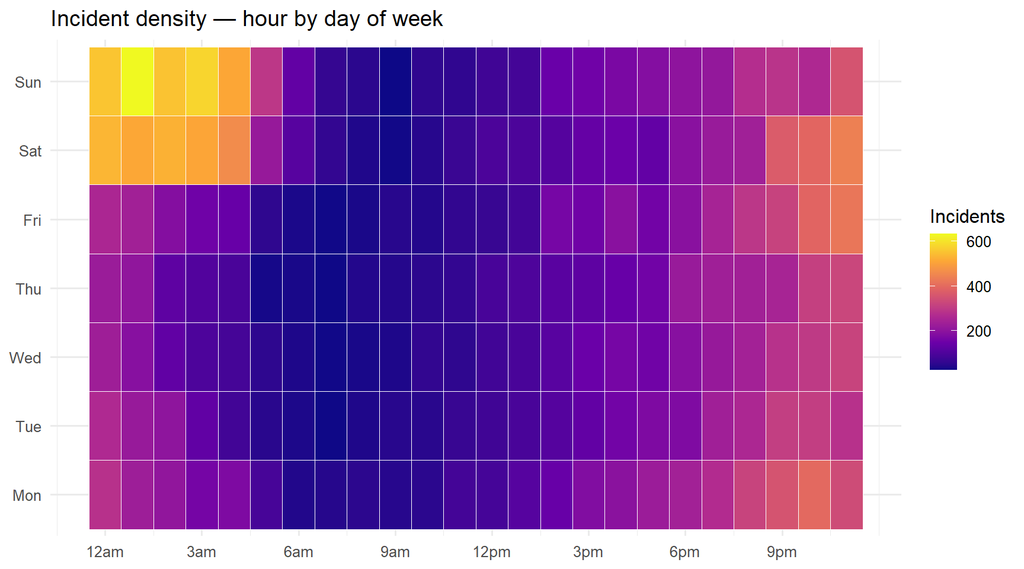

```r
shootings %>%
  count(wday, hour) %>%
  ggplot(aes(hour, wday, fill = n)) +
  geom_tile(color = "white", linewidth = 0.25) +
  scale_fill_viridis_c(option = "C", labels = comma) +
  scale_x_continuous(breaks = seq(0, 23, 3),
                     labels = c("12am","3am","6am","9am","12pm","3pm","6pm","9pm")) +
  labs(title = "Incident density — hour by day of week",
       x = NULL, y = NULL, fill = "Incidents") +
  theme_minimal(base_size = 12)
```